# Alternative TSSs that change the gene

Edward Wallace, ewjwallace@gmail.com

6th March 2018, rev 19 July 2019

# Summary

This document is focused on asking which candidate alternative TSSs could change the gene structure. It takes the alternative gene lists called as significant (1% FDR) from “TSS_alt_quant_negbin.Rmd” and asks which are in interesting different locations, e.g. in the coding region.

# H99

## load significant differences

## Find genes where the major TSS changes between condition

```
## # A tibble: 1,756 x 8
##    Gene_name  nMajSite nSites nLocations   Tot cdsAlt utr5Altx utr3Altx
##    <chr>         <int>  <int>      <int> <dbl> <lgl>  <lgl>    <lgl>
##  1 CNAG_00003        2      2          2    10 TRUE   FALSE    FALSE
##  2 CNAG_00004        4      4          2    46 TRUE   TRUE     FALSE
##  3 CNAG_00007        2      5          2   981 TRUE   FALSE    FALSE
##  4 CNAG_00013        2      3          2  1070 TRUE   TRUE     FALSE
##  5 CNAG_00017        3     10          3   127 TRUE   FALSE    FALSE
##  6 CNAG_00023        2      3          1   338 FALSE  TRUE     FALSE
##  7 CNAG_00024        2      2          2 13228 FALSE  FALSE    FALSE
##  8 CNAG_00032        2      2          2    14 TRUE   FALSE    FALSE
##  9 CNAG_00035        3      8          2   104 FALSE  TRUE     TRUE
## 10 CNAG_00039        3      6          2   697 TRUE   TRUE     FALSE
## # ... with 1,746 more rows
```

There are too many of these to be useful.

### High counts, and a TSS is in cds.

```
## # A tibble: 1,567 x 8
##    Gene_name  nMajSite nSites nLocations   Tot cdsAlt utr5Altx utr3Altx
##    <chr>         <int>  <int>      <int> <dbl> <lgl>  <lgl>    <lgl>
##  1 CNAG_01486        2      3          2 45953 TRUE   FALSE    FALSE
##  2 CNAG_06923        2      4          2 24991 TRUE   FALSE    FALSE
##  3 CNAG_01019        2      2          2 20799 TRUE   FALSE    FALSE
##  4 CNAG_02704        2      2          1 14963 TRUE   FALSE    FALSE
##  5 CNAG_03509        2      2          2 13078 TRUE   FALSE    FALSE
##  6 CNAG_00238        2      3          2 12793 TRUE   FALSE    FALSE
##  7 CNAG_05388        2      3          2 10731 TRUE   FALSE    FALSE
##  8 CNAG_04640        2      3          2 10064 TRUE   FALSE    FALSE
##  9 CNAG_01733        2      2          2  9228 TRUE   FALSE    FALSE
## 10 CNAG_00054        2      2          2  9205 TRUE   FALSE    FALSE
## # ... with 1,557 more rows
```

There are still too many of these to be useful.

### High counts, significant diff usage and a TSS is in cds.

```
## # A tibble: 982 x 8
##    Gene_name  nMajSite nSites nLocations   Tot cdsAlt utr5Altx utr3Altx
##    <chr>         <int>  <int>      <int> <dbl> <lgl>  <lgl>    <lgl>
##  1 CNAG_01486        2      3          2 45953 TRUE   FALSE    FALSE
##  2 CNAG_06923        2      4          2 24991 TRUE   FALSE    FALSE
##  3 CNAG_01019        2      2          2 20799 TRUE   FALSE    FALSE
##  4 CNAG_00238        2      3          2 12793 TRUE   FALSE    FALSE
##  5 CNAG_05388        2      3          2 10731 TRUE   FALSE    FALSE
##  6 CNAG_04640        2      3          2 10064 TRUE   FALSE    FALSE
##  7 CNAG_01733        2      2          2  9228 TRUE   FALSE    FALSE
##  8 CNAG_00054        2      2          2  9205 TRUE   FALSE    FALSE
##  9 CNAG_00047        2      3          3  8561 TRUE   FALSE    FALSE
## 10 CNAG_07695        2      2          2  8552 TRUE   FALSE    FALSE
## # ... with 972 more rows
```

There are still almost 1000 of these. We plot the top 36 here to get some ideas

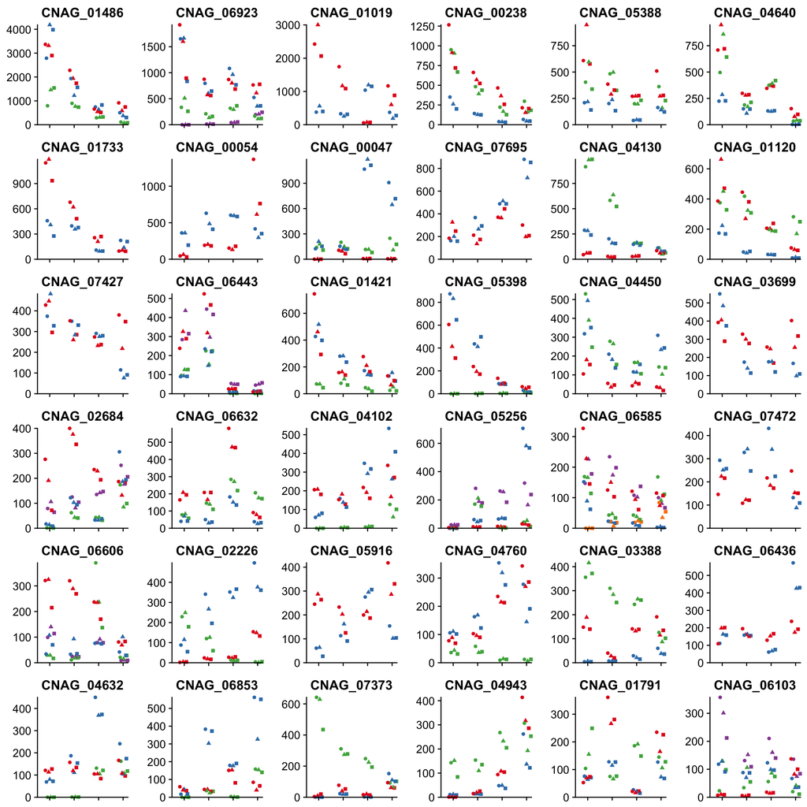

Those that look most interesting in terms of having a clear swap in TSS preference:

- CNAG_01486
- CNAG_01019 (SOD1)
- CNAG_01733?
- CNAG_00054
- CNAG_07695 This is a uORF-containing translationally repressed gene from paper.
- CNAG_01120?
- CNAG_07427 Casein kinase II?
- CNAG_03699 RNA helicase PRP5?
- CNAG_06632 ABC1 protein kinase?
- CNAG_04102 hypothetical protein
- CNAG_05256 Catalase CAT2
- CNAG_02226 hypothetical protein, peptidase/amidohydrolase AmhX homolog
- CNAG_05916 hypothetical protein, mutant resistant to manganese metalloporphyrin PMID:30291809
- CNAG_06436 hypothetical short protein with pred. signal peptide

### High counts, sig diff, a TSS is in cds, predicted mitochondrial localization

Using mitofates for the prediction

```
## # A tibble: 57 x 7
##    Gene_name  nMajSite nSites nLocations   Tot cdsAlt utr5Altx
##    <chr>         <int>  <int>      <int> <dbl> <lgl>  <lgl>
##  1 CNAG_01120        2      3          2  7763 TRUE   FALSE
##  2 CNAG_06632        2      3          2  5678 TRUE   FALSE
##  3 CNAG_04632        2      3          2  4567 TRUE   TRUE
##  4 CNAG_05497        2      3          2  3451 TRUE   FALSE
##  5 CNAG_06838        2      2          2  3389 TRUE   FALSE
##  6 CNAG_03920        2      4          2  2494 TRUE   FALSE
##  7 CNAG_05028        2      3          3  2274 TRUE   FALSE
##  8 CNAG_02095        3      3          2  2230 TRUE   TRUE
##  9 CNAG_04531        2      3          2  2130 TRUE   FALSE
## 10 CNAG_02074        2      3          2  2060 TRUE   FALSE
## # ... with 47 more rows
```

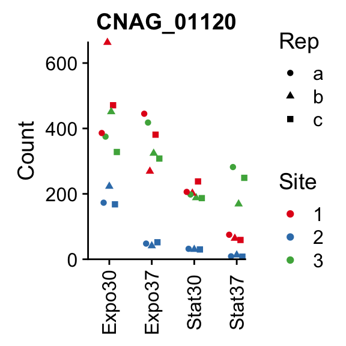

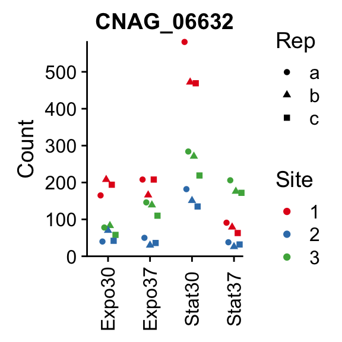

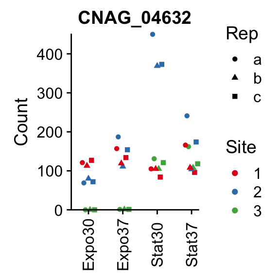

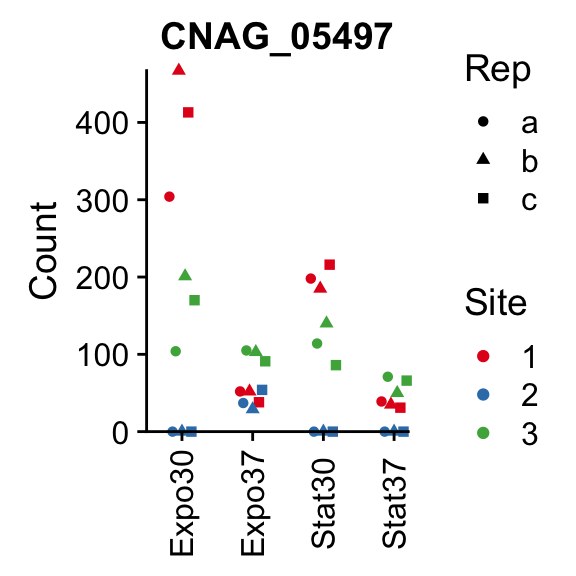

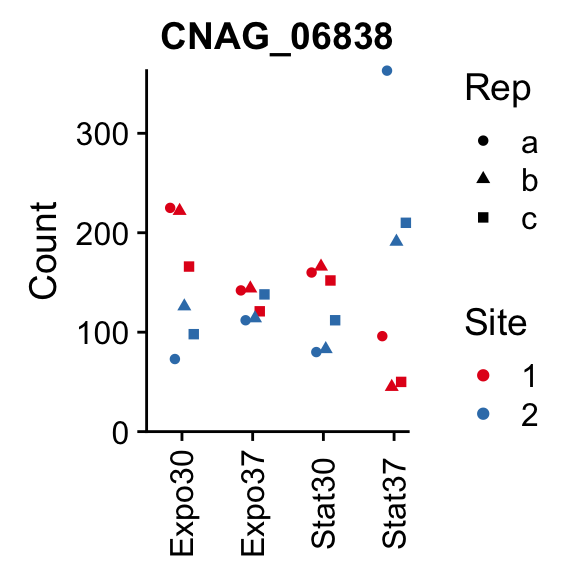

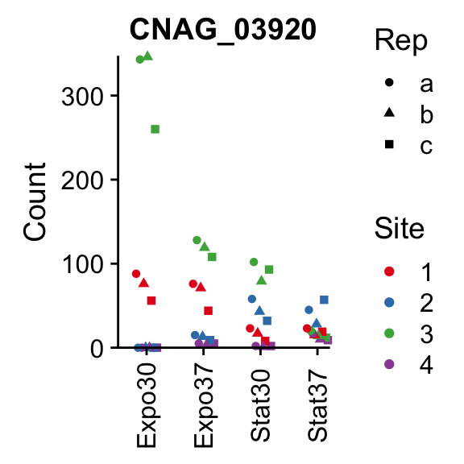

Now the numbers are getting low enough to be interpretable: 57 genes. This means there is *no* enrichment for mito. localized genes in those with sig diff and an alt TSS is in cds; it’s about 6% genome-wide.

- CNAG_01120, pyruvate dehydrogenase complex LAT1 homolog.
- CNAG_06632, ABC1 protein kinase
- CNAG_04632, uridine/uracil permease family, membrane-localized
- CNAG_05497, dihydroxy-acid dehydratase, ILV3 homolog
- CNAG_06838, mitochondrial ATP-dependent RNA helicase SUV3 homolog
- CNAG_03920, isocitrate dehydrogenase IDP1
- CNAG_02074, Mitochondrial processing peptidase subunit alpha, MAS2/MIF2 homolog

### High counts, sig diff, and alt TL / 5’UTR site

These could in principle change the 5’ end regulation. We should add those with suspected uORFs.

```
## # A tibble: 301 x 7
##    Gene_name  nMajSite nSites nLocations   Tot cdsAlt utr5Altx
##    <chr>         <int>  <int>      <int> <dbl> <lgl>  <lgl>
##  1 CNAG_05980        2      2          1 16853 FALSE  TRUE
##  2 CNAG_04963        2      2          1  9012 FALSE  TRUE
##  3 CNAG_04130        2      3          2  7906 TRUE   TRUE
##  4 CNAG_01421        2      3          3  6522 TRUE   TRUE
##  5 CNAG_01820        2      3          2  6037 FALSE  TRUE
##  6 CNAG_04102        2      3          3  5505 TRUE   TRUE
##  7 CNAG_00870        2      2          1  5142 FALSE  TRUE
##  8 CNAG_06606        2      4          2  5037 TRUE   TRUE
##  9 CNAG_02058        2      4          2  4947 FALSE  TRUE
## 10 CNAG_02226        2      3          2  4931 TRUE   TRUE
## # ... with 291 more rows
```

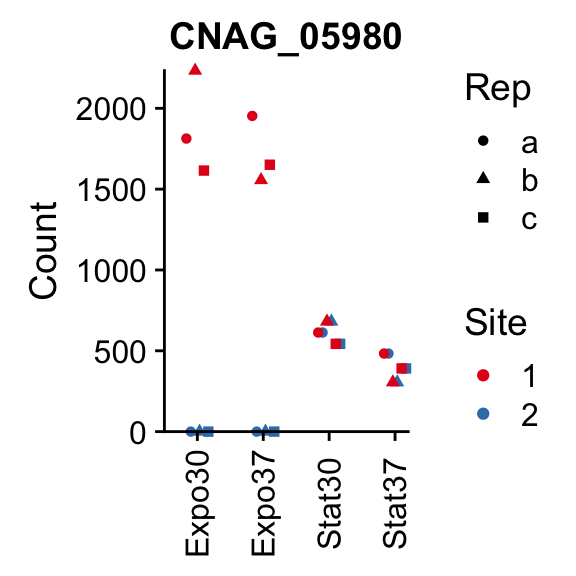

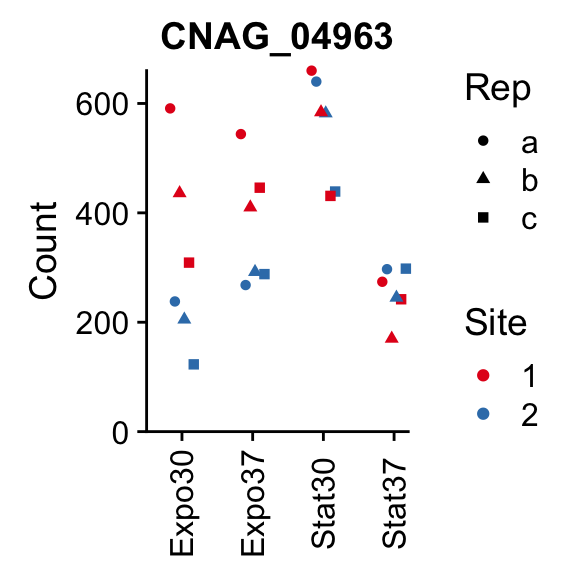

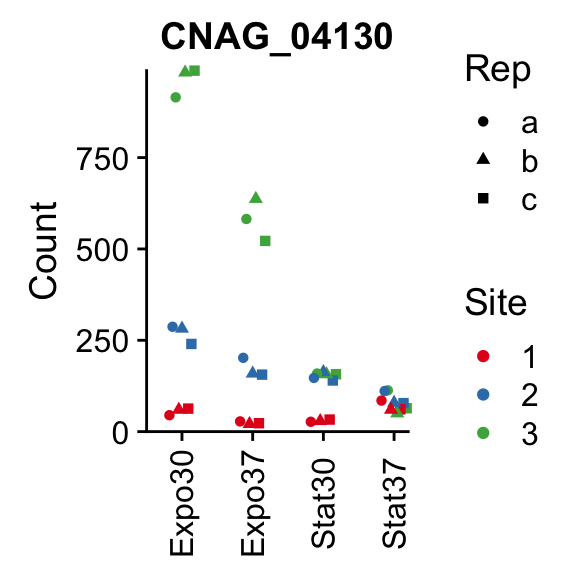

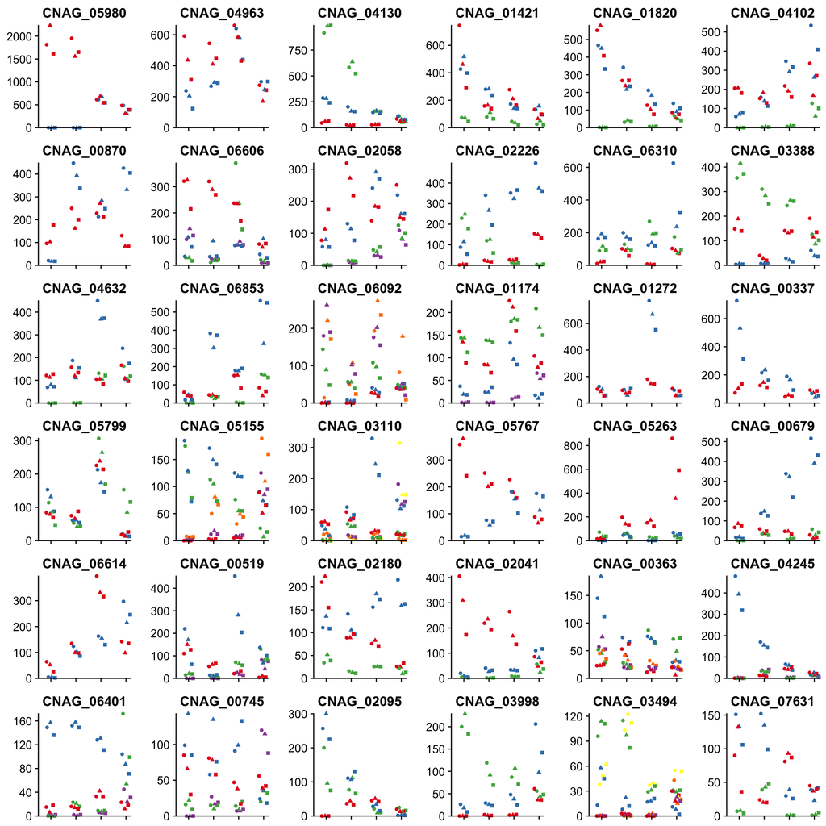

Interesting:

- CNAG_00870, hypothetical protein with 5’ utr introns.
- CNAG_03388, nuclear RPD3S histone deacetylase complex member, RCO1 homolog
- CNAG_01174 pheromone-regulated protein PRM10 homolog, duplications in other fungi.
- CNAG_05799 Chitin deacetylase CDA1
- CNAG_05155 protein-tyrosine-phosphatase PTP2
- CNAG_00679, hypothetical protein.
- CNAG_06614 glycerophosphodiesterase Pgc1
- CNAG_03998 MADS-box transcription factor RLM1
- CNAG_07631 hypothetical protein with predicted carbohydrate-binding domain